# PRACTICA2. Tipologia de Datos

## Preparación y analisis de un dataset

Script de preparación y análisis del Dataset "Wine Review". El objetivo planteado es verificar si existen relaciones significativas entre entre el precio de un vino, su valoración y la descripción que del mismo realiza un sommelier experto. Para simplificar el análisis, se tomará como elemento de valoración de la descripción la longitud de la misma. De este modo el analisis se centrará exclusivamente en valores numericos.

La numeración dada a cada apartado se corresponde con la del documento explicativo.

## 2.6.1. Análisis de conjunto

El proceso de análisis de conjunto identificará el número total de registros (muestras) del dataset, así como los atributos, sus tipos y las estadisticas generales de los datos (promedios, varianza, etc.).

```python
%matplotlib inline

import numpy as np
import pandas as pd
import matplotlib
import matplotlib.pyplot as plt
import seaborn as sns
import numpy as np
from numpy import percentile
from matplotlib import pyplot
from scipy import stats
from scipy.stats import normaltest

# Cargamos los datos del fichero "winemag-data-130k-v2.csv" en un dataframe

path = "C:/Users/Usuario/CloudStation/02 Emprender/03 HolaParlem/10 Biblioteca/06 Master Data Science UOC/97 Entregas/06 Tipologia de Datos/PRACTICA2/Dataset"
file_name="winemag-data-130k-v2.csv"
data = pd.read_csv(path + "/" + file_name)

def info(df):
    # Mostramos el número de muestras del fichero
    print ("Número de registros: " + str(len(df)) + "\n")

    # Mostramos el número de muestras del fichero
    print ("Número de atributos: " + str(len(df.columns)) + "\n")

    # Mostramos los atributos junto con el tipo asignado en la extracción
    print "Analisis del tipado de los datos:"
    print(df.dtypes)
    print ("\n")

    # Valores únicos de cada categoría/atributo
    print "Valores únicos por categoría:"
    print(data.nunique())
    print ("\n")

    # Analisis estadistico básico
    print "Analisis estadistico básico:"
    print (df.describe())
    print ("\n")

info(data)

# Visualizamos algunos datos (filas i a j)
print(data[1:10])
print ("\n")

# Nombramos los atributos que no están identificados (ID)
data.rename(columns={'Unnamed: 0':'id'}, inplace=True)
print (data.columns)
print ("\n")
```

```
Número de registros: 129971

Número de atributos: 14

Analisis del tipado de los datos:
Unnamed: 0                 int64
country                   object
description               object
designation               object
points                     int64
price                    float64
province                  object
region_1                  object
region_2                  object
taster_name               object
taster_twitter_handle     object
title                     object
variety                   object
winery                    object
dtype: object


Valores únicos por categoría:
Unnamed: 0               129971
country                      43
description              119955
designation               37979
points                       21
price                       390
province                    425
region_1                   1229
region_2                     17
taster_name                  19
taster_twitter_handle        15
title                    118840
variety                     707
winery                    16757
dtype: int64


```

[output cut: 57 more lines]

```
1      Portuguese Red  Quinta dos Avidagos
2          Pinot Gris            Rainstorm
3            Riesling           St. Julian
4          Pinot Noir         Sweet Cheeks
5  Tempranillo-Merlot               Tandem
6            Frappato      Terre di Giurfo
7      Gewürztraminer             Trimbach
8      Gewürztraminer          Heinz Eifel
9          Pinot Gris   Jean-Baptiste Adam


Index([u'id', u'country', u'description', u'designation', u'points', u'price',
       u'province', u'region_1', u'region_2', u'taster_name',
       u'taster_twitter_handle', u'title', u'variety', u'winery'],
      dtype='object')
```

## Conclusiones:

1.- El número total de registros es de: 129.971 2.- El número de vinos diferentes es muy alto (prácticamente hay un registro por vino) 3.- 707 variedades de uva 4.- Vinos de hasta 43 paises diferentes 5.- Los tipos de las variables numericas asignadas por defecto son coherentes a su función. No se realizarán cambios en ellas. 6.- Se nombra el atributo (de origen vacio), cuya función es identificar cada registro como 'id'. 7.- Todas las puntuaciones de los vinos identificados son superiores a 80, que es consistente con la información proporcionada en la página origen de los datos. 8.- El precio se encuentra concentrado en una horquilla de hasta 50 €, observandose la existencia de valores muy por debajo y muy por encima de la media. En consecuencia el análisis de valores extremos debe ser considerado particularmente relevante en este caso.

## 2.6.4. Limpieza

### 2.6.4.1.- Selección de atributos

A priori el 'taster_name', el 'taster_twitter_handle', 'region_1', 'region_2' podrian eliminarse del dataset para su simplificación, ya que son variables que no contemplamos dentro de este análisis y de esta forma aligeramos el tratamiento de datos. Hay otras variables que tampoco forman parte del análisis pero preferimos no eliminarlas puesto que consideramos que pueden ser utiles de cara a completar posibles valores faltantes. Por otra parte incorporamos la longitud del texto de la descripcion como variable adicional.

```python
# Separamos los registros que no son de interés del dataset, eliminandolas

del data['taster_name']
del data['taster_twitter_handle']
del data['region_1']
del data['region_2']
data['descrip_length'] =data.description.str.len()
data.head(5)
```

|  | id | country | description | designation | points | price | province | title | variety | winery | descrip_length |
| --- | --- | --- | --- | --- | --- | --- | --- | --- | --- | --- | --- |
| 0 | 0 | Italy | Aromas include tropical fruit, broom, brimston... | Vulkà Bianco | 87 | NaN | Sicily & Sardinia | Nicosia 2013 Vulkà Bianco (Etna) | White Blend | Nicosia | 172 |
| 1 | 1 | Portugal | This is ripe and fruity, a wine that is smooth... | Avidagos | 87 | 15.0 | Douro | Quinta dos Avidagos 2011 Avidagos Red (Douro) | Portuguese Red | Quinta dos Avidagos | 227 |
| 2 | 2 | US | Tart and snappy, the flavors of lime flesh and... | NaN | 87 | 14.0 | Oregon | Rainstorm 2013 Pinot Gris (Willamette Valley) | Pinot Gris | Rainstorm | 186 |
| 3 | 3 | US | Pineapple rind, lemon pith and orange blossom ... | Reserve Late Harvest | 87 | 13.0 | Michigan | St. Julian 2013 Reserve Late Harvest Riesling ... | Riesling | St. Julian | 199 |
| 4 | 4 | US | Much like the regular bottling from 2012, this... | Vintner's Reserve Wild Child Block | 87 | 65.0 | Oregon | Sweet Cheeks 2012 Vintner's Reserve Wild Child... | Pinot Noir | Sweet Cheeks | 249 |

### 2.6.4.2.- Duplicados

Buscamos si existen muestras duplicadas.

```python
# Creamos una fila que identifique si hay duplicados
data['esta_duplicado']= data.duplicated()
print("El número de muestras duplicadas es de %d.") %len(data[data['esta_duplicado']==True])
# Eliminamos la fila creada
del data['esta_duplicado']
```

```
El número de muestras duplicadas es de 0.
```

### 2.6.4.3.- Análisis de registros vacíos o nulos

En primer lugar identificamos el número de registros vacios para cada atributo:

```python
# Contamos los registros vacios y calculamos el porcentaje que representan
def vacios(df):
    muestras_vacias = df.isnull().sum()
    # identificamos su peso en cada caso:
    total_registros = np.product(df.shape)
    total_vacias = muestras_vacias.sum()
    return ((float(total_vacias)/float(total_registros)) * 100)


print ("El numero de muestras vacias representa el %f porciento del total.") %vacios(data)


# verificamos que los campos vacios encontrados tanto en 'country' como en 'province' corresponden a las mismas muestras,
#al observar que ambos campos tienen el mismo numero de registros vacios.
if (len(data.loc[data.title.isin(data[data.country.isnull() & data.province.isnull()].title)])==len(data[data.country.isnull()])):
    print('Las muestras de country vacias tambien tienen province vacio')
else:
    print('Las muestras de country vacias NO coinciden necesariamente con province vacio')

# verificamos si podemos completar la información de variedad faltante (dado que solo hay un registro)
# a partir del texto de descripcion o del titulo del vino
pd.set_option('display.max_colwidth', -1)
print(data[data.variety.isnull()].title)
print(data[data.variety.isnull()].description)
pd.set_option('display.max_colwidth', 50)
```

```
El numero de muestras vacias representa el 3.258629 porciento del total.
Las muestras de country vacias tambien tienen province vacio
86909    Carmen 1999  (Maipo Valley)
Name: title, dtype: object
86909    A chalky, dusty mouthfeel nicely balances this Petite Syrah's bright, full blackberry and blueberry fruit. Wheat-flour and black-pepper notes add interest to the bouquet; the wine finishes with herb and an acorny nuttiness. A good first Chilean wine for those more comfortable with the Calif…
Name: description, dtype: object
```

## Decisiones:

1.- Eliminamos todos aquellos registros con algun campo de interés nulo. Dado que 'designation' no va a formar parte de dicho estudio, para evitar reducir en exceso el dataset, lo completamos como 'Unknow' y así lo mantendremos posteriormente al eliminar el resto que son vacios.

```python
# Etiquetamos como desconocidos los campos vacios del atributo designation para mantenerlos
data['designation'] = data.designation.replace(np.NaN, 'Unknown')
# Eliminamos los registros vacios distinguiendo los casos en que los atributos son numericos o cadenas de texto.
atributtes=list(data)
for column_name in atributtes:
    if ((column_name != 'id') | (column_name != 'points') | (column_name != 'price')):
        data = data[pd.notnull(data[column_name])]
    else:
        data.dropna(axis=0, subset=[column_name])

# Comprobamos que hemos eliminado los registros vacios
info(data)
print ("El numero de muestras vacias representa el %f por ciento del total.") %vacios(data)
```

```
Número de registros: 120915

Número de atributos: 11

Analisis del tipado de los datos:
id                  int64
country            object
description        object
designation        object
points              int64
price             float64
province           object
title              object
variety            object
winery             object
descrip_length      int64
dtype: object


Valores únicos por categoría:
id                120915
country               42
description       111511
designation        35754
points                21
price                390
province             422
title             110582
variety              691
winery             15843
descrip_length       566
dtype: int64


Analisis estadistico básico:
                  id         points          price  descrip_length
count  120915.000000  120915.000000  120915.000000   120915.000000
mean    65043.605541      88.421726      35.368796      244.528826
std     37511.733783       3.044954      41.031188       66.792224
min         1.000000      80.000000       4.000000       20.000000
25%     32571.500000      86.000000      17.000000      199.000000
50%     65141.000000      88.000000      25.000000      239.000000
75%     97501.500000      91.000000      42.000000      284.000000
max    129970.000000     100.000000    3300.000000      829.000000


El numero de muestras vacias representa el 0.000000 por ciento del total.
```

### 2.6.4.4.- Outliers

Procedemos a la identificación de valores extremos para los registros numericos de precio, valoracion y longitud del texto de descripcion. Lo hacemos mediante analisis visual y aplicando el test de D'Agostino's (se ha considerado este test puesto que el numero de registros disponibles es elevado)

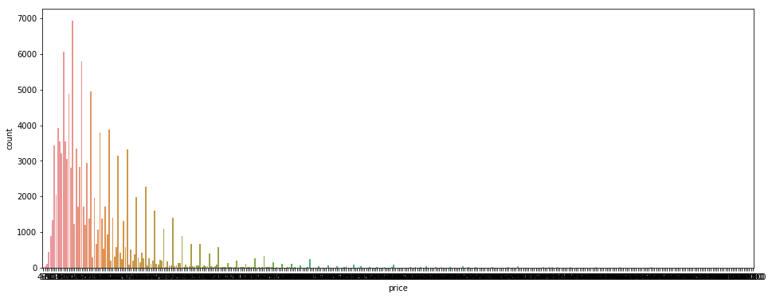

```
Statistics=255566.952, p=0.000
Las muestras no siguen una distribución normal.
```

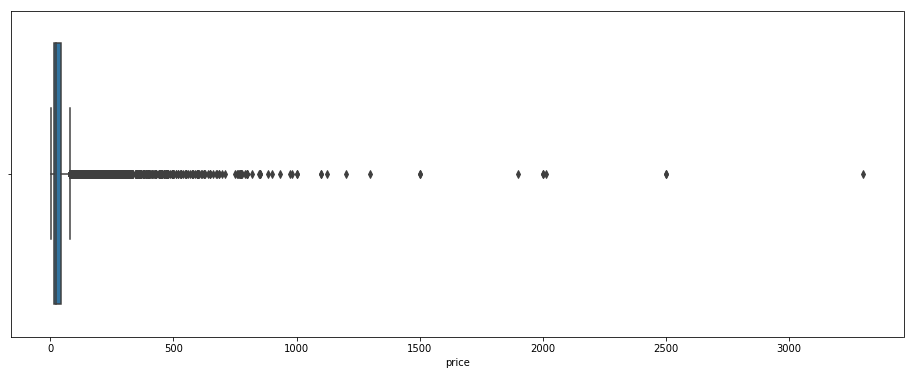

```
Percentiles: 25th=17.000, 75th=42.000, IQR=25.000
Outliers: 7241
```

```python
# Outliers: analisis del registro de precio

#comprobamos visualmente la normalidad
plt.figure(figsize=(16,6))
plt.subplot(1,1,1)
g = sns.countplot(x='price', data=data)
plt.show()

#comprobamos la normalidad mediante test (D’Agostino’s K^2 Test)
stat, p = normaltest(data['price'])
print('Statistics=%.3f, p=%.3f' % (stat, p))
# interpretamos el resultado
alpha = 0.05
if p > alpha:
    print('Las muestras parecen seguir una distribución normal')
else:
    print('Las muestras no siguen una distribución normal.')


#identificamos visualmente los outliers
plt.figure(figsize=(16,6))
plt.subplot(1,1,1)
sns.boxplot(x=data['price'])
plt.show()


# identificar los outliers considerando que la muestra no es normal. (Metodo de intercuartiles)
q25, q75 = percentile(data['price'], 25), percentile(data['price'], 75)
iqr = q75 - q25
print('Percentiles: 25th=%.3f, 75th=%.3f, IQR=%.3f' % (q25, q75, iqr))
# calculamos los puntos de corte de los outliers
cut_off = iqr * 1.5
lower_price, upper_price = q25 - cut_off, q75 + cut_off
# identificamos los outliers
outliers = [x for x in data['price'] if x < lower_price or x > upper_price]
print('Outliers: %d' % len(outliers))
```

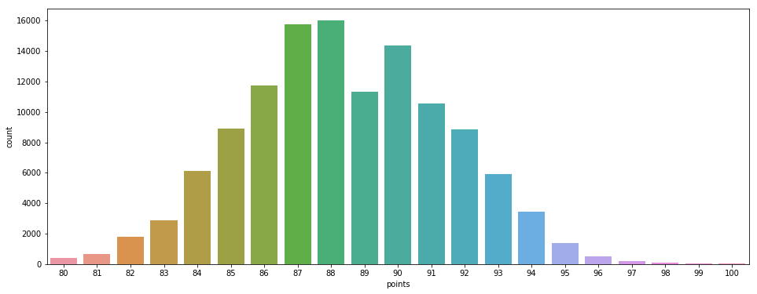

```
Statistics=625.634, p=0.000
Las muestras no siguen una distribución normal.
```

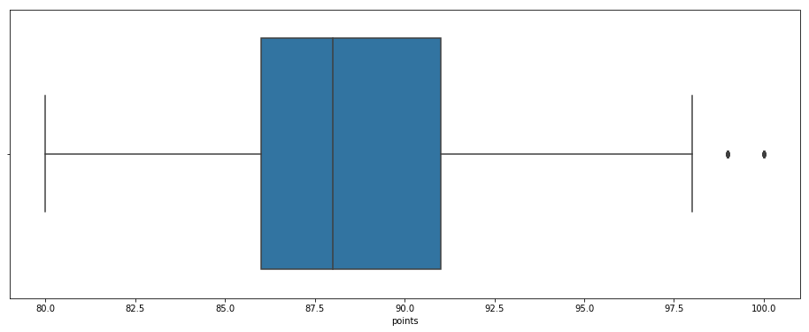

```
Percentiles: 25th=86.000, 75th=91.000, IQR=5.000
Outliers: 47
```

```python
# Outliers: analisis del registro de puntos

#comprobamos visualmente la normalidad
plt.figure(figsize=(16,6))
plt.subplot(1,1,1)
g = sns.countplot(x='points', data=data)
plt.show()

#comprobamos la normalidad mediante test (D’Agostino’s K^2 Test)
stat, p = normaltest(data['points'])
print('Statistics=%.3f, p=%.3f' % (stat, p))
# interpret
alpha = 0.05
if p > alpha:
    print('Las muestras parecen seguir una distribución normal')
else:
    print('Las muestras no siguen una distribución normal.')


#identificamos visualmente los outliers
plt.figure(figsize=(16,6))
plt.subplot(1,1,1)
sns.boxplot(x=data['points'])
plt.show()


# identificar los outliers considerando que la muestra no es normal. (Metodo de intercuartiles)
q25, q75 = percentile(data['points'], 25), percentile(data['points'], 75)
iqr = q75 - q25
print('Percentiles: 25th=%.3f, 75th=%.3f, IQR=%.3f' % (q25, q75, iqr))
# calculamos los puntos de corte de los outliers
cut_off = iqr * 1.5
lower_points, upper_points = q25 - cut_off, q75 + cut_off
# identificamos los outliers
outliers = [x for x in data['points'] if x < lower_points or x > upper_points]
print('Outliers: %d' % len(outliers))
```

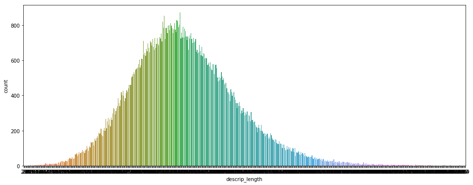

```
Statistics=8771.603, p=0.000
Las muestras no siguen una distribución normal.
```

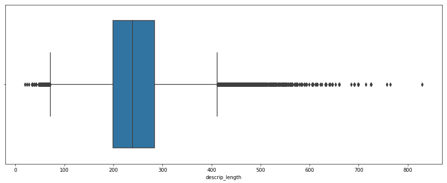

```
Percentiles: 25th=199.000, 75th=284.000, IQR=85.000
Outliers: 1961
```

```python
# Outliers: analisis del registro de longitud de la descripcion

#comprobamos visualmente la normalidad
plt.figure(figsize=(16,6))
plt.subplot(1,1,1)
g = sns.countplot(x='descrip_length', data=data)
plt.show()

#comprobamos la normalidad mediante test (D’Agostino’s K^2 Test)
stat, p = normaltest(data['descrip_length'])
print('Statistics=%.3f, p=%.3f' % (stat, p))
# interpret
alpha = 0.05
if p > alpha:
    print('Las muestras parecen seguir una distribución normal')
else:
    print('Las muestras no siguen una distribución normal.')


#identificamos visualmente los outliers
plt.figure(figsize=(16,6))
plt.subplot(1,1,1)
sns.boxplot(x=data['descrip_length'])
plt.show()


# identificar los outliers considerando que la muestra no es normal. (Metodo de intercuartiles)
q25, q75 = percentile(data['descrip_length'], 25), percentile(data['descrip_length'], 75)
iqr = q75 - q25
print('Percentiles: 25th=%.3f, 75th=%.3f, IQR=%.3f' % (q25, q75, iqr))
# calculamos los puntos de corte de los outliers
cut_off = iqr * 1.5
lower_desc, upper_desc = q25 - cut_off, q75 + cut_off
# identificamos los outliers
outliers = [x for x in data['descrip_length'] if x < lower_desc or x > upper_desc]
print('Outliers: %d' % len(outliers))
```

## Conclusiones

1.- Aunque visualmente tanto los atributos points como description_lenght parecen seguir una distribución normal, los test nos indican que no es así. 2.- Por ello hemos utilizado el método de intercuartiles para detectar los outliers. 3.- El número de outliers es muy elevado en el caso del precio (como ya se adelantaba) y también en el caso de las longitudes de la descripción.

## Decisiones

```python
# eliminamos los outliers de precio y longitud de descripcion obtenidos
data=data[((data['price']>= lower_price) & (data['price']<= upper_price))]
data=data[((data['descrip_length']>= lower_desc) & (data['descrip_length']<= upper_desc))]
info(data)
```

```
Número de registros: 112184

Número de atributos: 11

Analisis del tipado de los datos:
id                  int64
country            object
description        object
designation        object
points              int64
price             float64
province           object
title              object
variety            object
winery             object
descrip_length      int64
dtype: object


Valores únicos por categoría:
id                112184
country               42
description       103212
designation        32987
points                20
price                 76
province             420
title             102362
variety              684
winery             15476
descrip_length       340
dtype: int64


Analisis estadistico básico:
                  id         points          price  descrip_length
count  112184.000000  112184.000000  112184.000000   112184.000000
mean    64978.984427      88.140261      28.958506      238.846734
std     37494.805895       2.870649      16.092037       60.565256
min         1.000000      80.000000       4.000000       72.000000
25%     32470.750000      86.000000      16.000000      196.000000
50%     65106.500000      88.000000      25.000000      236.000000
75%     97373.250000      90.000000      39.000000      279.000000
max    129970.000000      99.000000      79.000000      411.000000
```

### 2.6.4.5.- Salvamos el fichero preparado

Procedemos a salvar el fichero con los datos preparados. El conjunto de registros final es de: 112184, con 11 atributos.

```python
# Guardar un csv
data.to_csv("data_prepared.csv")
```

## 2.7.- Analisis

Para proceder al análisis de la relacion existente entre el precio, la valoración y la longitud de la descripción realizaremos un análisis de correlación. Ya hemos verificado previamente que ninguna de las variables presenta un comportamiento normal. Es por ello que realizaremos el cálculo del coeficiente de correlación de las diferentes variables con respecto al precio utilizando el coeficiente de Spearman.

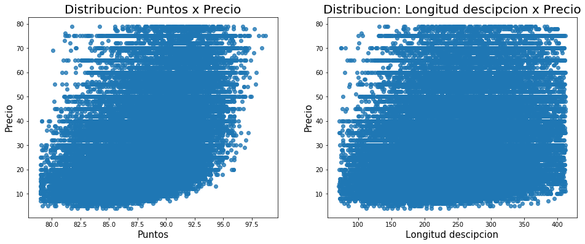

```
0.56110164333
0.331556718665
```

```python
#carga de librerias estadísticas (necesarias para el calculo del coeficiente de correlacion)
from scipy.stats import spearmanr

# cargamos el fichero con los datos preparados
path = "C:/Users/Usuario/00 Practicas UOC"
file_name="data_prepared.csv"
data = pd.read_csv(path + "/" + file_name)

#Analisis gráfico previo
plt.figure(figsize=(16,6))
plt.subplot(1,2,1)
g = sns.regplot(x='points', y='price', data=data, x_jitter=True, fit_reg=False)
g.set_title("Distribucion: Puntos x Precio", fontsize=20)
g.set_xlabel("Puntos", fontsize= 15)
g.set_ylabel("Precio", fontsize= 15)
plt.subplot(1,2,2)
g = sns.regplot(x='descrip_length', y='price', data=data, x_jitter=True, fit_reg=False)
g.set_title("Distribucion: Longitud descipcion x Precio", fontsize=20)
g.set_xlabel("Longitud descipcion", fontsize= 15)
g.set_ylabel("Precio", fontsize= 15)
plt.show()

#Calculo del coeficiente de cortrelación de spearman
corr, p_value = spearmanr(data['price'], data['points'])
print corr

corr, p_value = spearmanr(data['price'], data['descrip_length'])
print corr
```

## Conclusiones

Considerando que en el rango [-1,1] ambos valores son positivos, observamos que en ambos casos hay influencia entre las variables, si bien el atributo de valoracion es mas infuyente en el precio que la longitd de la descripción.